# Project_Part1_VaishaliPawar_SFML

Name :- Vaishali Kailash Pawar Student Number :- 0559388 Study Programme :- Master of Science in Applied Sciences and Engineering : Computer Science(Artificial Intelligence) Title of Project:- Classification

```python
import pandas as pd
import numpy as np
import matplotlib.pyplot as plt
import timeit
import pylab
import random
%matplotlib inline
```

Importing the Dataset

```python
 url = "https://raw.githubusercontent.com/hajdeger/AOP_PUB/master/bill_authentication.csv"
```

```python
 data = pd.read_csv(url)
```

```python
data
```

|  | Variance | Skewness | Curtosis | Entropy | Class |
| --- | --- | --- | --- | --- | --- |
| 0 | 3.62160 | 8.66610 | -2.8073 | -0.44699 | 0 |
| 1 | 4.54590 | 8.16740 | -2.4586 | -1.46210 | 0 |
| 2 | 3.86600 | -2.63830 | 1.9242 | 0.10645 | 0 |
| 3 | 3.45660 | 9.52280 | -4.0112 | -3.59440 | 0 |
| 4 | 0.32924 | -4.45520 | 4.5718 | -0.98880 | 0 |
| ... | ... | ... | ... | ... | ... |
| 1367 | 0.40614 | 1.34920 | -1.4501 | -0.55949 | 1 |
| 1368 | -1.38870 | -4.87730 | 6.4774 | 0.34179 | 1 |
| 1369 | -3.75030 | -13.45860 | 17.5932 | -2.77710 | 1 |
| 1370 | -3.56370 | -8.38270 | 12.3930 | -1.28230 | 1 |
| 1371 | -2.54190 | -0.65804 | 2.6842 | 1.19520 | 1 |

1372 rows × 5 columns

Data Analysis

We can use the following command to produce the shape of the loaded DataFrame:

```python
data.shape
```

```
(1372, 5)
```

```python
data.head()
```

|  | Variance | Skewness | Curtosis | Entropy | Class |
| --- | --- | --- | --- | --- | --- |
| 0 | 3.62160 | 8.6661 | -2.8073 | -0.44699 | 0 |
| 1 | 4.54590 | 8.1674 | -2.4586 | -1.46210 | 0 |
| 2 | 3.86600 | -2.6383 | 1.9242 | 0.10645 | 0 |
| 3 | 3.45660 | 9.5228 | -4.0112 | -3.59440 | 0 |
| 4 | 0.32924 | -4.4552 | 4.5718 | -0.98880 | 0 |

Preparing the Data

```python
X = data.drop('Class', axis=1)
y = data['Class']
```

```python
#X = data.drop('P_value', axis=1)
#y = data['P_value']
```

spiltting the data into training and test set is as follows:

```python
from sklearn.model_selection import train_test_split
X_train, X_test, y_train, y_test = train_test_split(X, y, test_size = 0.20)
```

```python
X
```

|  | Variance | Skewness | Curtosis | Entropy |
| --- | --- | --- | --- | --- |
| 0 | 3.62160 | 8.66610 | -2.8073 | -0.44699 |
| 1 | 4.54590 | 8.16740 | -2.4586 | -1.46210 |
| 2 | 3.86600 | -2.63830 | 1.9242 | 0.10645 |
| 3 | 3.45660 | 9.52280 | -4.0112 | -3.59440 |
| 4 | 0.32924 | -4.45520 | 4.5718 | -0.98880 |
| ... | ... | ... | ... | ... |
| 1367 | 0.40614 | 1.34920 | -1.4501 | -0.55949 |
| 1368 | -1.38870 | -4.87730 | 6.4774 | 0.34179 |
| 1369 | -3.75030 | -13.45860 | 17.5932 | -2.77710 |
| 1370 | -3.56370 | -8.38270 | 12.3930 | -1.28230 |
| 1371 | -2.54190 | -0.65804 | 2.6842 | 1.19520 |

1372 rows × 4 columns

Classification Problem :-

Classification is the problem of identifying to which of a set of categories a new observation belongs, on the basis of a training set of data containing instances or observations whose category membership is known. Examples are assigning a given email to the "spam" or "non-spam" class, and assigning a diagnosis to a given patient based on observed characteristics of the patient such sex, blood pressure, symptoms, age, etc.

ML algorithms are implemented as follow on above datasets:

# Support Vector Machine

One of the type of supervised machine learning classification algorithm is a support vector machine. Support vector machine is now becoming so popular beacause of its ability to get the intelligent results. When we compare it with the other machine learning algorithms, Support vector machines are implemented in the unique way.

Simple SVM:-

For the linearly seperable data in two dimensions, A machine learning algorithm will try to find out the boundary in such a way that there will be less misclassification errors. There can be multiple boundaries that correctly divide the data points. there can be a dashed lines as well as solid line which classify the data points correctly. This is the case with the typical machine learning algorithm. SVM differs from such a classification algorithm in such a way that it choose the decision boundary that maximizes the distance from the nearest data points of all the classes. In other words, we can say that the SVM finds the most optimal boundary for deviding the data points, rather just a decision boundary.

Let assume the {${(X_{n},y_{n})}$ : $X_{n}$ $\in R^{d} $ and $y_n \in$ {$ {-1,1}$}} be a training set, where n = 1,··· ,N. The hypothesis set of the basic support vector machine or SVM is as follows:

$H_{SVM}$ = {h $\in$ H : h(x) = sign($w^T$ x + b)}

where w is the weight vector orthogonal to the hyperplane h(x) = 0 and b is the intercept, the intersection of the hyperplane with the y-axis.

The basic SVM is a classiﬁcation algorithm which assumes that the data are linearly separable. It returns the maximum margin hyperplane. This is the solution to the constrained optimization problem. Minimize the objective function.

$\frac{1}{2} w^T w$

it subjects to the constraints:

$ y_n(w^T x_n + b) \geq 0 $ for n = 1,··· ,N

The objective function is quadratic and the constraints are linear.

The weight vector and the intercept of the ﬁnal hypothesis g(x) = $ w^T x+b$ are given by -

w = $\sum _{n=1}^{N} \alpha_n y_n X_n $

$ y_s(w^T x_s + b) = 1 $

In this case, ${x_s}$ is any of the support vectors.

Most $\alpha_n$ = 0. When $\alpha_n$ > 0, the corresponding xn is called a support vector. Above equation gives the constraint to be satisﬁed by the corresponding support vector ${x_s}$ and gives the intercept b.

The basic SVM can be extended in 2 ways. A ﬁrst way is to apply a non-linear transformation Φ: X → Z : x → z = Φ(x) from the input space to the feature space. The maximum margin separation is done in Z. To accomplish this, SVM uses the kernel trick. A kernel function K : X × X → R is positive deﬁnite: K (x, x') > 0 for all non-zero vectors x, x' ∈ X. A kernel K induces a transformation $Φ_K$ to a feature space $Z_K$ but both are left implicit.

The polynomial krnel is as follows:

${K_{poly}(x,x')} = (X^T x' + 1)^d$

In this case, d is the radial basis kernel and it is a positive integer

${K_{rb}(x, x')} = exp(- \gamma \vert \vert x - x' \vert \vert^2)$

where γ > 0 is a real constant

The final hypothesis is as follows:

${g(x) = sign(\sum _{\alpha_{n>0}}^{} \alpha_n y_n K(X_n , X) + b)}$

where ${b = y_s - \sum _{\alpha_{n>0}}^{} \alpha_n y_n K(X_n , X_s)}$ for any of the support vectors ${X_s}.$

All the compuations in the above equation are done in the input space X.

Next thing is to allow the misclassification. The variable ${\zeta_n \geq 0}$ measures the degree of misclassification for each ${x_n}$. if ${\zeta_n = 0}$ then it is classified correctly. And if ${\zeta_n > 0}$ then x is misclassified.

Minimization of the objective function is as follows:

$\frac{1}{2} w^T w + C \sum _{{n=1}}^{N} \zeta_n $

It is subject to the constraints

${y_n(w^T x_n + b) >= 1 - \zeta_n}$

${\zeta_n >= 0}$ for n = 1, ....., N.

Optimal decision boundary :-

The most optimal decision boundary is the one which has maximum margin from the nearest points of all the classes. support vectors are the nearest points from the decision boundary that maximize the distance between the decision boundary. In support vector machines, the decision boundary is called as the maximum margin classifier, or the maximum margin hyper plane. There is a lot of mathematics involved in finding the support vectors, calculating margin between decision boundary, maximizing this margin and the support vectors.

SVM and Kernel SVM are implemented using the Python Scikit-Learn library as follow:.

Importing libraries:

The following script imports required libraries:

```python
from sklearn.svm import SVC
```

Training the Algorithm:-

For training the algorithm, We have to first divide the data into training and testing sets. After that we can train our SVM model on the training set. Scikit-Learn contains the svm library, which contains built-in classes for different SVM algorithms. Here, we are going to perform a task of classificattion, we can use the support vector classifier class. The support vector classifier class is written as SVC in the Scikit-Learn's svm library. The parameter of this class is kernel type. In the case of a simple SVM, we can simply set this parameter as "linear" since simple SVMs can only classify linearly separable data. To train the algorithm on the training data, the fit method of SVC class should be called. The code to train the algorithm is as follows:-

```python
from sklearn.svm import SVC
svclassifier = SVC(kernel='linear')
svclassifier.fit(X_train, y_train)
```

```
SVC(C=1.0, cache_size=200, class_weight=None, coef0=0.0,
    decision_function_shape='ovr', degree=3, gamma='auto_deprecated',
    kernel='linear', max_iter=-1, probability=False, random_state=None,
    shrinking=True, tol=0.001, verbose=False)
```

To make predictions, the predict method of the SVC class is used. Following code shows the predictions using the predict method:

```python
y_pred = svclassifier.predict(X_test)
```

Evaluating the Algorithm :-

The most commonly used metrics for classification tasks are Confusion matrix, precision, recall, and F1 measures. Scikit-Learn's metrics library contains the classification_report and confusion_matrix methods, which can be used to find out the values for these metrics.

The code is as follows:

```python
from sklearn.metrics import classification_report, confusion_matrix
print(confusion_matrix(y_test,y_pred))
print(classification_report(y_test,y_pred))
```

```
[[160   3]
 [  1 111]]
              precision    recall  f1-score   support

           0       0.99      0.98      0.99       163
           1       0.97      0.99      0.98       112

    accuracy                           0.99       275
   macro avg       0.98      0.99      0.98       275
weighted avg       0.99      0.99      0.99       275
```

Kernel SVM

Previous section shows how the simple SVM algorithm can be used to find decision boundary for linearly separable data. A straight line cannot be used as a decision boundary, in the case of non-linearly separable data. A modified version of SVM which is called as Kernel SVM is used in the case of non-linearly separable data. The simple SVM algorithm is not used in the case of non-linearly separable data.

Following is the implementation of Kernel SVM with Scikit-Learn

To train the algorithm, fit method should be called. We use the same SVC class of the Scikit-Learn's svm library. The difference will be in the value of kernel parameter of SVC class. For the simple SVM we used "linear" as the value for the kernel parameter. However, for kernel SVM you can use Gaussian, polynomial, sigmoid, or computable kernel.

```python
from sklearn.svm import SVC
svclassifier = SVC(kernel='poly', degree=8)
svclassifier.fit(X_train, y_train)
```

```
SVC(C=1.0, cache_size=200, class_weight=None, coef0=0.0,
    decision_function_shape='ovr', degree=8, gamma='auto_deprecated',
    kernel='poly', max_iter=-1, probability=False, random_state=None,
    shrinking=True, tol=0.001, verbose=False)
```

The prediction is as follows:

```python
y_pred = svclassifier.predict(X_test)
```

The implementation of the confusion matrics is as follows:

```python
from sklearn.metrics import classification_report, confusion_matrix
print(confusion_matrix(y_test, y_pred))
print(classification_report(y_test, y_pred))
```

```
[[159   4]
 [  1 111]]
              precision    recall  f1-score   support

           0       0.99      0.98      0.98       163
           1       0.97      0.99      0.98       112

    accuracy                           0.98       275
   macro avg       0.98      0.98      0.98       275
weighted avg       0.98      0.98      0.98       275
```

Below is the implementation of polynomial, Gaussian, and sigmoid kernels.

1. Polynomial Kernel

In the case of polynomial kernel, you have to pass a value for the degree parameter of the SVC class. This basically is the degree of the polynomial. We can use a polynomial kernel to implement kernel SVM:

```python
from sklearn.svm import SVC
svclassifier = SVC(kernel='poly', degree=8)
svclassifier.fit(X_train, y_train)
```

```
SVC(C=1.0, cache_size=200, class_weight=None, coef0=0.0,
    decision_function_shape='ovr', degree=8, gamma='auto_deprecated',
    kernel='poly', max_iter=-1, probability=False, random_state=None,
    shrinking=True, tol=0.001, verbose=False)
```

After training the model, next step is to make the predictions on the test data.

```python
y_pred = svclassifier.predict(X_test)
```

Evaluating the Algorithm:-

The final step is evaluationg the model. The model is evaluated as follows:-

```python
from sklearn.metrics import classification_report, confusion_matrix
print(confusion_matrix(y_test, y_pred))
print(classification_report(y_test, y_pred))
```

```
[[159   4]
 [  1 111]]
              precision    recall  f1-score   support

           0       0.99      0.98      0.98       163
           1       0.97      0.99      0.98       112

    accuracy                           0.98       275
   macro avg       0.98      0.98      0.98       275
weighted avg       0.98      0.98      0.98       275
```

2. Gaussian Kernel

```python
from sklearn.svm import SVC
svclassifier = SVC(kernel='rbf')
svclassifier.fit(X_train, y_train)
```

```
SVC(C=1.0, cache_size=200, class_weight=None, coef0=0.0,
    decision_function_shape='ovr', degree=3, gamma='auto_deprecated',
    kernel='rbf', max_iter=-1, probability=False, random_state=None,
    shrinking=True, tol=0.001, verbose=False)
```

We have to specify 'rbf' as a value for the Kernel parameter of the SVC class to use Gaussian kernel.

Prediction and Evaluation

The prediction on test data is as follow:-

```python
y_pred = svclassifier.predict(X_test)
```

The model is evaluated as follows:-

```python
from sklearn.metrics import classification_report, confusion_matrix
print(confusion_matrix(y_test, y_pred))
print(classification_report(y_test, y_pred))
```

```
[[163   0]
 [  0 112]]
              precision    recall  f1-score   support

           0       1.00      1.00      1.00       163
           1       1.00      1.00      1.00       112

    accuracy                           1.00       275
   macro avg       1.00      1.00      1.00       275
weighted avg       1.00      1.00      1.00       275
```

3. Sigmoid Kernel

We can use sigmoid kernel for implementing Kernel SVM, The script is as follows:-

```python
from sklearn.svm import SVC
svclassifier = SVC(kernel='sigmoid')
svclassifier.fit(X_train, y_train)
```

```
SVC(C=1.0, cache_size=200, class_weight=None, coef0=0.0,
    decision_function_shape='ovr', degree=3, gamma='auto_deprecated',
    kernel='sigmoid', max_iter=-1, probability=False, random_state=None,
    shrinking=True, tol=0.001, verbose=False)
```

For using the sigmoid kernel, you have to specify 'sigmoid' as value for the kernel parameter of the SVC class.

Prediction and Evaluation

Prediction on test data is as follows:-

```python
y_pred = svclassifier.predict(X_test)
```

The output of the Kernel SVM with Sigmoid kernel looks like this:

```python
from sklearn.metrics import classification_report, confusion_matrix
print(confusion_matrix(y_test, y_pred))
print(classification_report(y_test, y_pred))
```

```
[[98 65]
 [55 57]]
              precision    recall  f1-score   support

           0       0.64      0.60      0.62       163
           1       0.47      0.51      0.49       112

    accuracy                           0.56       275
   macro avg       0.55      0.56      0.55       275
weighted avg       0.57      0.56      0.57       275
```

# Logistic Regression

In various classification problems, logistic regression can be used. One of the example can be spam detection. It is the most simple and commonly used machine learning algorithms for two-class classification. It is easy to implement and it can be used as the baseline for any binary classification problem. Its fundamental concepts can be also very much constructive in the case of deep learning. It is a statistical method of predicting the binary classes. The outcome or target variable is dichotomous in nature. Dichotomous means there are only two possible classes.

Logistic regression is the special case of the linear regression where the target variable is the categorical in nature. It uses the log of odds as a dependent variable. It predicts the probability of occurrence of a binary event utilizing a logit function.

Linear Regression Equation:

y = $ \beta0 + \beta1 X1 + \beta2 X2 + .... + \beta n Xn $

In this case, y is dependent variable and x1, x2 ... and Xn are explanatory variables.

Logistic regression provides a constant output. Some of the examples of the discrete output is that predicting whether a person has a cancer or not, whether or not the transaction is fraud. logistic regression is estimated using Maximum Likelihood Estimation approach.

Linear Regression Vs. Logistic Regression

Logistic regression provides the constant output, but the linear regression gives the continuous output. In the example of a continuous output, we can say house price and stock price. Example's of the discrete output is predicting whether a patient has cancer or not, predicting whether the customer will churn. Linear regression is estimated using Ordinary Least Squares (OLS) while logistic regression is estimated using Maximum Likelihood Estimation (MLE) approach.

Sigmoid Function

The sigmoid function is also called as a logistic function. It gives the 'S' shaped curve that can take any real-valued number and it will map it into a value between 0 and 1. if the curve goes to negative infinity, y predicted will become 0. And we can say, if it goes to positive infinity, y predicted will become 1. If the output of the sigmoid function is more than 0.5, we can classify the outcome as 1 or YES, and if it is less than 0.5, we can classify it as 0 or NO. And if the output is 0.75, we can say in terms of probability as there is a 75 percent chance that patient will suffer from cancer.

Logistic model models the probability of output response ¥ belonging to a particular category.

We can say:

${p(X) = \frac{e^{\beta_0 + \beta_1 x}}{1 + e^{\beta_0 + \beta_1 x} }}$

By applying componendo dividendo we can get:

$ => {\frac{p(X)}{1 - p(x)} = \frac{e^{\beta_0 + \beta_1 x}}{1 + e^{\beta_0 + \beta_1 x} }}$

which is nothing but the odds:

$ => {ln(\frac{p(X)}{1 - p(x)}) = \beta_0 + \beta_1 X}$

We can use maximum likelihood for estimating the beta coefficients. The basic idea is to estimate the betas such that the estimated value and observed value of the results are as close as possible. In a binary classification, with observed classes as 1 and 0, we can say the likelihood function would look like:

${l(\beta_0 , \beta_1) = \prod_{i : y_i = 1}} p^\wedge(x_i)\prod_{ i : y_i = 0} ( 1 - p^\wedge(x_i^\sim)) $

Model Development and Prediction

For developing the model, first we need to import the Logistic Regression module and create a Logistic Regression classifier object using LogisticRegression() function. After that, we need to fit the model on the train set using fit() and perform prediction on the test set using predict().

```python
from sklearn.linear_model import LogisticRegression
#create an instance and fit the model
logmodel = LogisticRegression()
logmodel.fit(X_train, y_train)
```

```
LogisticRegression(C=1.0, class_weight=None, dual=False, fit_intercept=True,
                   intercept_scaling=1, l1_ratio=None, max_iter=100,
                   multi_class='warn', n_jobs=None, penalty='l2',
                   random_state=None, solver='warn', tol=0.0001, verbose=0,
                   warm_start=False)
```

The predictions on the test set is as follows:-

```python
#predictions
Predictions = logmodel.predict(X_test)
```

Model evaluation is as follows :-

```python
from sklearn.metrics import classification_report
print(classification_report(y_test,Predictions))
```

```
              precision    recall  f1-score   support

           0       0.99      0.98      0.99       163
           1       0.97      0.99      0.98       112

    accuracy                           0.99       275
   macro avg       0.98      0.99      0.98       275
weighted avg       0.99      0.99      0.99       275
```

Model Evaluation using Confusion Matrix

For evaluationg the performance of a classification model, we can use a confusion matrix. It is a table used for evaluating the performance of a classification model. Using the confusion matrix, you can visualize the performance of an algorithm. In confusion matrix the number of correct and incorrect predictions are summed up class-wise.

```python
# import the metrics class
from sklearn import metrics
cnfmatrix = metrics.confusion_matrix(y_test, Predictions)
cnfmatrix
```

```
array([[160,   3],
       [  1, 111]], dtype=int64)
```

Above is the confusion matrix in the form of the array object. The dimension of this matrix is 2*2. This is because this model is binary classification. You have two classes 0 and 1. Diagonal values represent accurate predictions, while non-diagonal elements are inaccurate predictions.

```python
# import required modules
import numpy as np
import matplotlib.pyplot as plt
import seaborn as sns
%matplotlib inline
```

Visualizing Confusion Matrix using Heatmap:

We can visualize the results of the model in the form of a confusion matrix using matplotlib and seaborn. The visualization of the confusion matrix using Heatmap is as follows:-

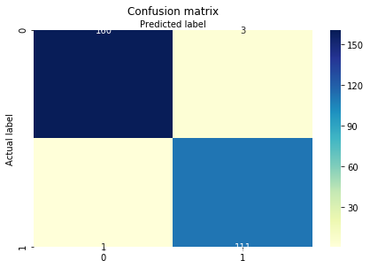

```python
nameclas=[0,1] # name  of classes
f, aax = plt.subplots()
tmarks = np.arange(len(nameclas))
plt.xticks(tmarks, nameclas)
plt.yticks(tmarks, nameclas)
# create heatmap
sns.heatmap(pd.DataFrame(cnfmatrix), annot=True, cmap="YlGnBu" ,fmt='g')
aax.xaxis.set_label_position("top")
plt.tight_layout()
plt.title('Confusion matrix', y=1.1)
plt.ylabel('Actual label')
plt.xlabel('Predicted label')
```

Confusion Matrix Evaluation Metrics

```python
print("Accuracy:",metrics.accuracy_score(y_test, Predictions))
print("Precision:",metrics.precision_score(y_test, Predictions))
print("Recall:",metrics.recall_score(y_test, Predictions))
```

```
Accuracy: 0.9854545454545455
Precision: 0.9736842105263158
Recall: 0.9910714285714286
```

Here, we got a good classification rate, considered as good accuracy.

Precision:

Precision is about being precise, i.e., determining how accurate the model is. In other words, we can say, when a model makes a prediction, how often it is correct.

ROC Curve

Receiver Operating Characteristic(ROC) curve is a plot of the true positive rate against the false positive rate. It shows the tradeoff between sensitivity and specificity.

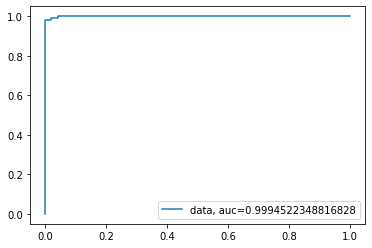

```python
ypredproba = logmodel.predict_proba(X_test)[::,1]
f, t, _ = metrics.roc_curve(y_test,  ypredproba)
au = metrics.roc_auc_score(y_test, ypredproba)
plt.plot(f,t,label="data, auc="+str(au))
plt.legend(loc=4)
plt.show()
```

AUC score for the case is 0.99. AUC score 1 represents perfect classifier, and 0.5 represents a worthless classifier.

# k nearest neighbor

Another supervised machine learning algorithm is K-nearest neighbors (KNN). The KNN algorithm performs quite complex classification tasks though its extremely easy to implement in its most basic form. KNN does not have any specialized training phase. it uses all of the data for training while classifying a new data point or instance. It is a non-parametric learning algorithm. This means that it does not assume anything about the underlying data. This is the most useful feature about the data because many of the real world data doesn't follow any theoretical assumption. As a example, we can say that assumptions such as linear-separability, uniform distribution, etc.

Another important feature about the K nearest neighbor is that it is the simplest of all the supervised machine learning algorithms. It simply calculates the distance of a new data point to all the other training data points. The distance can be calculated using any type such as Euclidean or Manhattan etc. It then selects the K-nearest data points, where K can be of any integer. After that it assigns the data points to the class for which majority of k points belong.

When KNN is used for the purpose of classification, the output can be calculated as the class with the highest frequency from the K-most similar instances. Each instance votes for their class and the class with the most votes is taken as the predictions.

Working of KNN

For example, suppose the task is to classify a new data point ‘X’ into 'Blue' class or 'Red' class.

Steps involved in working of K Nearest Neighbour:- -The algorithm first starts by determining the position of the unknown value X. For example Let’s say the coordinate values of the data points are x=45 and y=50. Now the KNN algorithm takes an appropriate value of K. Here, K indicates the number of neighbours to consider while applying KNN algorithm. This value of K is mostly provided by user. The value of K should be optimised to get the good model. Suppose the value of K is 3. After that, the KNN algorithm starts calculating the distance of point X from all the other points. The distance can be calculated using some methods such as euclidean, manhattan, etc.It then finds the 3 i.e. K = 3 nearest points with least distance to point X. The final step of the KNN algorithm is to assign a new point to the class to which the majority of the three nearest points belong. As a example we can say that if two of the three nearest points belong to the class 'Red' while one belongs to the class 'Blue', then new data point will be classified as 'Red'.

Distance measurement :-

Euclidean distance:

We can calculate the Euclidean distance as the square root of the sum of the squared differences between a new point and an existing point across all input attributes. This is most widely used for distance measurement for the new data point from all the other data points.

Feature Scaling :-

It is always a good practice to scale the features, before making any actual predictions, so that all of them can be uniformly evaluated. The gradient descent algorithm also converges faster with normalized features. The gradient descent algorithm is mostly used in neural network training and other machine learning algorithms.

The following script performs feature scaling:

```python
from sklearn.preprocessing import StandardScaler
scaler = StandardScaler()
scaler.fit(X_train)
X_train = scaler.transform(X_train)
X_test = scaler.transform(X_test)
```

Training and Predictions

When using the Scikit-Learn, It is extremely straight forward to train the KNN algorithm and make predictions with it.

```python
from sklearn.neighbors import KNeighborsClassifier
classifier = KNeighborsClassifier(n_neighbors=5)
classifier.fit(X_train, y_train)
```

```
KNeighborsClassifier(algorithm='auto', leaf_size=30, metric='minkowski',
                     metric_params=None, n_jobs=None, n_neighbors=5, p=2,
                     weights='uniform')
```

The first step is to import the KNeighborsClassifier class from the sklearn library. After that we can initialize that class with one parameter, i.e. n_neigbours. This is the value for the K. There is no ideal value for K and it is selected after testing and evaluation, however to start out, 5 seems to be the most commonly used value for KNN algorithm.

The final step is to make predictions on our test data. To do so, we can execute the following script:

```python
ypredk = classifier.predict(X_test)
```

Evaluating the Algorithm:-

The most commonaly used metrics for evaluating an algorithm are confusion matrix, precision, recall and f1 score. The confusion_matrix and classification_report methods of the sklearn.metrics can be used to calculate these metrics. The script can be executed as follows:

```python
from sklearn.metrics import classification_report, confusion_matrix
print(confusion_matrix(y_test, ypredk))
print(classification_report(y_test, ypredk))
```

```
[[163   0]
 [  0 112]]
              precision    recall  f1-score   support

           0       1.00      1.00      1.00       163
           1       1.00      1.00      1.00       112

    accuracy                           1.00       275
   macro avg       1.00      1.00      1.00       275
weighted avg       1.00      1.00      1.00       275
```

The results show that our KNN algorithm was able to classify all the records in the test set with 100% accuracy, which is good accuracy. KNN does not always perform good with high-dimensionality or categorical features.

Comparing Error Rate with the K Value

There is no way to predict beforehand which value of k produces the best results. In the above examples we randomly choose the value of k. One way to find the best value of k is to plot the graph of k value and the corresponding error rate for the dataset. Below, there is a implementation and graph of a mean error for the predicted values of test set for all the K values between 1 and 40.

Let's first calculate the mean of error for all the predicted values where K ranges from 1 and 40. Execute the following script:

```python
error = []

# Calculating error for K values between 1 and 40
for i in range(1, 40):
    knn = KNeighborsClassifier(n_neighbors=i)
    knn.fit(X_train, y_train)
    predi = knn.predict(X_test)
    error.append(np.mean(predi != y_test))
```

In the above script there is a loop execuation from 1 to 40. In each iteration the mean error for predicted values of test set is calculated and the result is appended to the error list.

The next step is to plot the error values against K values. Following script is to create the plot:

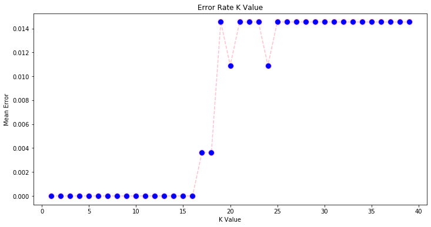

```python
plt.figure(figsize=(12, 6))
plt.plot(range(1, 40), error, color='pink', linestyle='dashed', marker='o',
         markerfacecolor='blue', markersize=10)
plt.title('Error Rate K Value')
plt.xlabel('K Value')
plt.ylabel('Mean Error')
```

Optimal value of k can be achieved by using the k-fold cross-validation. It involves estimating the test error rate by holding out a subset of the training set from the fitting process. We will use a 10-fold cross-validation on our dataset using a generated list of odd K’s ranging from 1–50.

```python
# creating odd list of K for KNN

from sklearn.model_selection import cross_val_score, KFold
neighbors = list(range(1, 50, 2))

# empty list that will hold cv scores
cv_scores = []

# perform 10-fold cross validation
for k in neighbors:
    knn = KNeighborsClassifier(n_neighbors=k)
    scores = cross_val_score(knn, X_train, y_train, cv=10, scoring='accuracy')
    cv_scores.append(scores.mean())
```

```
The optimal number of neighbors is 3
```

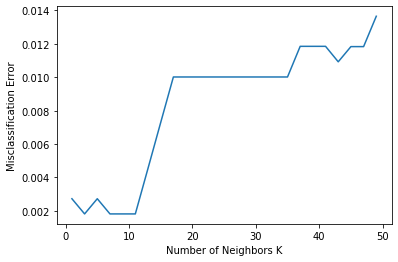

```python
# changing to misclassification error
mse = [1 - x for x in cv_scores]

# determining best k
optimal_k = neighbors[mse.index(min(mse))]
print("The optimal number of neighbors is {}".format(optimal_k))

# plot misclassification error vs k
plt.plot(neighbors, mse)
plt.xlabel("Number of Neighbors K")
plt.ylabel("Misclassification Error")
plt.show()
```

KNN is a simple yet powerful classification algorithm. It requires no training for making predictions. Training for making predictions is typically one of the most difficult parts of a machine learning algorithm. The KNN algorithm have been widely used to find pattern recognition and document similarity.

# Synthetic Data

```python
import warnings
import pandas as pd
import matplotlib.pyplot as plt
from mpl_toolkits.mplot3d import Axes3D
from matplotlib.colors import ListedColormap
import seaborn as sns
import numpy as np
from sklearn.decomposition import PCA
from sklearn.datasets import make_classification
from scipy.stats import norm
from sklearn.preprocessing import StandardScaler
from scipy import stats
from scipy.stats import norm, skew
from sklearn.svm import SVC
#import plotly.offline as py
#py.init_notebook_mode(connected=True)
#from plotly import tools
#import plotly.graph_objs as go

warnings.filterwarnings('ignore')
get_ipython().magic(u'matplotlib inline')
pd.set_option('display.float_format', lambda x: '{:.3f}'.format(x))
color = sns.color_palette()
sns.set(style='ticks', palette="muted", color_codes=True)
```

Here, we can start by generating a random classification problem with four features and three classes:

```python
 X_, y_ = make_classification(n_features=4, n_samples=150, n_classes=3, class_sep=2, n_redundant=0, n_informative=4,
                             n_clusters_per_class=1, random_state=0)
```

Next, we construct a pandas DataFrame from our generated numpy array with labeled columns, then we can combine our feature and target columns:

```python
X = pd.DataFrame(X_)
X.columns = ['A', 'B', 'C', 'D']

y = pd.DataFrame(y_)
y.columns = ['Target']

df = pd.concat([X, y], axis=1)
```

```python
df.head(5)
```

|  | A | B | C | D | Target |
| --- | --- | --- | --- | --- | --- |
| 0 | -2.360 | 1.750 | -2.497 | -2.251 | 0 |
| 1 | -2.220 | 1.210 | -2.349 | -1.352 | 0 |
| 2 | 1.548 | -1.547 | -0.440 | -0.139 | 1 |
| 3 | -0.299 | -1.358 | 1.228 | 3.451 | 1 |
| 4 | -3.630 | -1.985 | 3.247 | 1.495 | 1 |

```python
df
```

|  | A | B | C | D | Target |
| --- | --- | --- | --- | --- | --- |
| 0 | -2.360 | 1.750 | -2.497 | -2.251 | 0 |
| 1 | -2.220 | 1.210 | -2.349 | -1.352 | 0 |
| 2 | 1.548 | -1.547 | -0.440 | -0.139 | 1 |
| 3 | -0.299 | -1.358 | 1.228 | 3.451 | 1 |
| 4 | -3.630 | -1.985 | 3.247 | 1.495 | 1 |
| ... | ... | ... | ... | ... | ... |
| 145 | 1.742 | -1.478 | -2.201 | -2.006 | 2 |
| 146 | -3.010 | -0.998 | 3.110 | 0.776 | 1 |
| 147 | -2.268 | -1.099 | 2.783 | 0.151 | 1 |
| 148 | 1.857 | -1.472 | -2.523 | -1.707 | 2 |
| 149 | -2.300 | 1.850 | -2.182 | -1.742 | 0 |

150 rows × 5 columns

```python
df.Target.value_counts()
```

```
2    50
1    50
0    50
Name: Target, dtype: int64
```

In this case, we have an equal number of observations in each class. We can plot a first two features 'A' and 'B' and we can see how the target classes are clustered.

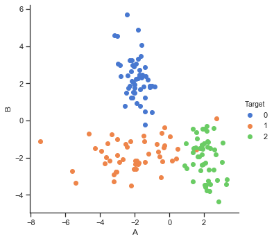

```python
sns.FacetGrid(df, hue="Target", size=5).map(plt.scatter, "A", "B").add_legend();
```

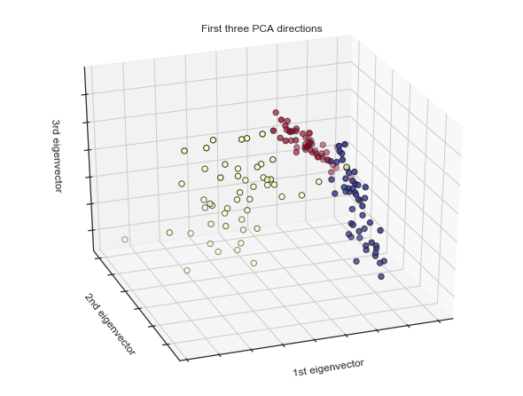

```python
X_3D = X_[:, :2]

x_min, x_max = X_3D[:, 0].min() - .5, X_3D[:, 0].max() + .5
y_min, y_max = X_3D[:, 1].min() - .5, X_3D[:, 1].max() + .5

fig = plt.figure(1, figsize=(8, 6))
ax = Axes3D(fig, elev=-150, azim=110)
X_reduced = PCA(n_components=3).fit_transform(X)
ax.scatter(X_reduced[:, 0], X_reduced[:, 1], X_reduced[:, 2], c=y_,
           cmap=plt.cm.RdYlBu, edgecolor='k', s=40)
ax.set_title("First three PCA directions")
ax.set_xlabel("1st eigenvector")
ax.w_xaxis.set_ticklabels([])
ax.set_ylabel("2nd eigenvector")
ax.w_yaxis.set_ticklabels([])
ax.set_zlabel("3rd eigenvector")
ax.w_zaxis.set_ticklabels([])

plt.show()
```

A few more visualizations to understand the relationships in our data:

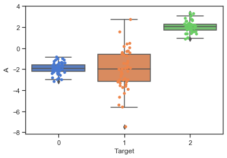

```python
ax = sns.boxplot(x="Target", y="A", data=df)
ax = sns.stripplot(x="Target", y="A", data=df, jitter=True, edgecolor="gray")
```

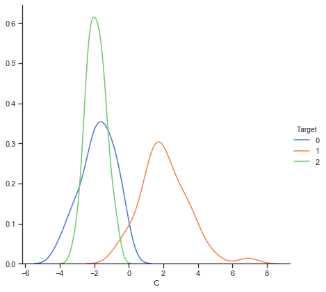

```python
sns.FacetGrid(df, hue="Target", size=6).map(sns.kdeplot, "C").add_legend();
```

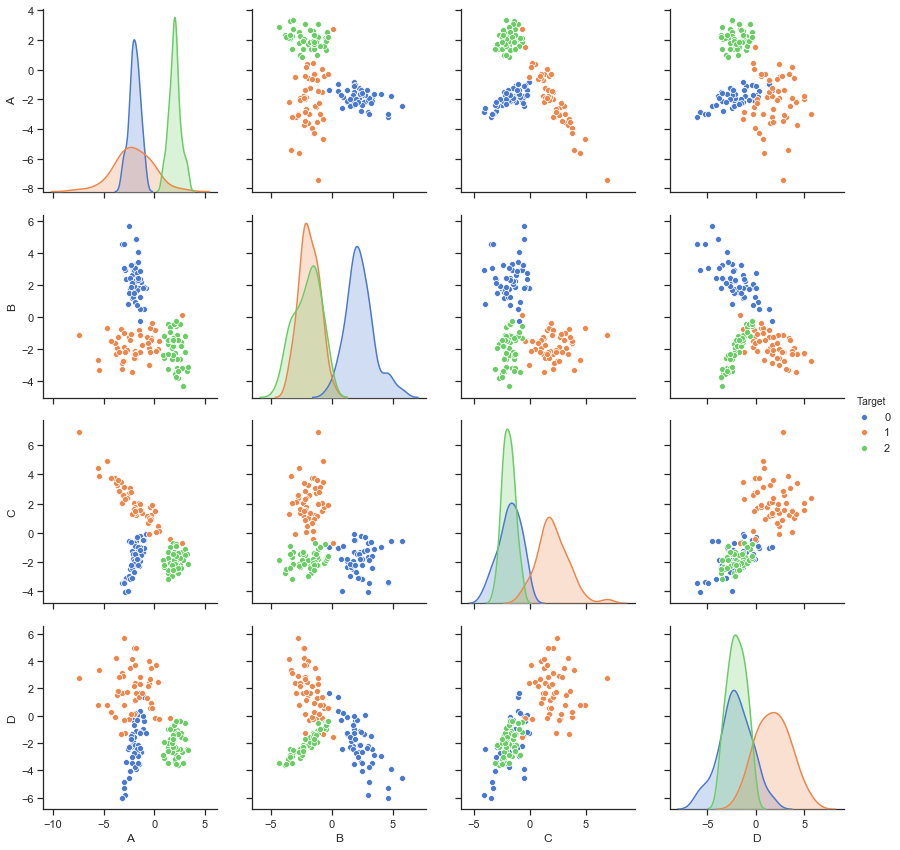

```python
sns.pairplot(df, hue="Target", vars=["A", "B", "C", "D"], diag_kind="kde", size=3);
```

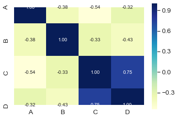

```python
corrmat = X.corr()
cols = X.columns
sns.set(font_scale=1.25)
hm = sns.heatmap(corrmat, cbar=True, annot=True, square=True, cmap='YlGnBu', fmt='.2f', annot_kws={'size': 10}, yticklabels=cols.values, xticklabels=cols.values)
plt.show()
```

Now here we have a good sense of our data. We can get ready for the classification problem:

```python
#from sklearn.model_selection import train_test_split

#train, test  = train_test_split(df, test_size = 0.3)

#print('Training set shape: ', train.shape)
#print('Test set shape: ', test.shape)
```

```python
#X_train, X_test, y_train, y_test = train_test_split(train, test)
```

```python
df.shape
```

```
(150, 5)
```

```python
X = df.drop('Target', axis=1)
y = df['Target']
```

```python
from sklearn.model_selection import train_test_split
Xtrain, Xtest, ytrain, ytest = train_test_split(X, y, test_size = 0.20)
```

```python
X
```

|  | A | B | C | D |
| --- | --- | --- | --- | --- |
| 0 | -2.360 | 1.750 | -2.497 | -2.251 |
| 1 | -2.220 | 1.210 | -2.349 | -1.352 |
| 2 | 1.548 | -1.547 | -0.440 | -0.139 |
| 3 | -0.299 | -1.358 | 1.228 | 3.451 |
| 4 | -3.630 | -1.985 | 3.247 | 1.495 |
| ... | ... | ... | ... | ... |
| 145 | 1.742 | -1.478 | -2.201 | -2.006 |
| 146 | -3.010 | -0.998 | 3.110 | 0.776 |
| 147 | -2.268 | -1.099 | 2.783 | 0.151 |
| 148 | 1.857 | -1.472 | -2.523 | -1.707 |
| 149 | -2.300 | 1.850 | -2.182 | -1.742 |

150 rows × 4 columns

# k nearest neighbor

Generating Model for K=5

We can build a K nearest neighbor classifier model for k=5 as follows:

```python
#Import knearest neighbors Classifier model
from sklearn.neighbors import KNeighborsClassifier

#Create KNN Classifier
knn = KNeighborsClassifier(n_neighbors=5)

#Train the model using the training sets
knn.fit(Xtrain, ytrain)

#Predict the response for test dataset
ypred = knn.predict(Xtest)
```

```python
#Import scikit-learn metrics module for accuracy calculation
from sklearn import metrics
# Model Accuracy, how often is the classifier correct?
print("Accuracy:",metrics.accuracy_score(ytest, ypred))
```

```
Accuracy: 0.9333333333333333
```

Re-generating Model for K=7 Let's build KNN classifier model for k=7.

```python
#Import knearest neighbors Classifier model
from sklearn.neighbors import KNeighborsClassifier

#Create KNN Classifier
knn = KNeighborsClassifier(n_neighbors=7)

#Train the model using the training sets
knn.fit(Xtrain, ytrain)

#Predict the response for test dataset
ypred = knn.predict(Xtest)
```

```python
#Import scikit-learn metrics module for accuracy calculation
from sklearn import metrics
# Model Accuracy, how often is the classifier correct?
print("Accuracy:",metrics.accuracy_score(ytest, ypred))
```

```
Accuracy: 0.9666666666666667
```

Feature Scaling

We can scale the features so that all of them can be uniformaly evaluated, before making any actual predictions.

The gradient descent algorithm also converges faster with normalized features.

```python
from sklearn.preprocessing import StandardScaler
scaler = StandardScaler()
scaler.fit(Xtrain)

Xtrain = scaler.transform(Xtrain)
Xtest = scaler.transform(Xtest)
```

The following script performs feature scaling:

```python
from sklearn.preprocessing import StandardScaler
scaler = StandardScaler()
scaler.fit(Xtrain)

Xtrain = scaler.transform(Xtrain)
Xtest = scaler.transform(Xtest)
```

Training and Predictions

The model can be trained as follows, using Scikit-Learn.

```python
from sklearn.neighbors import KNeighborsClassifier
classifier = KNeighborsClassifier(n_neighbors=5)
classifier.fit(Xtrain, ytrain)
```

```
KNeighborsClassifier(algorithm='auto', leaf_size=30, metric='minkowski',
                     metric_params=None, n_jobs=None, n_neighbors=5, p=2,
                     weights='uniform')
```

The first step is to import the KNeighborsClassifier class from the sklearn.neighbors library. In the second line, this class is initialized with one parameter, i.e. n_neigbours. This is basically the value for the K. There is no ideal value for K and it is selected after testing and evaluation.

The final step is to make predictions on our test data. To do so, we can execute the following script:

```python
ypred = classifier.predict(Xtest)
```

Evaluating the Algorithm

The confusion metrics is evaluated as follows:

```python
from sklearn.metrics import classification_report, confusion_matrix
print(confusion_matrix(ytest, ypred))
print(classification_report(ytest, ypred))
```

```
[[14  0  0]
 [ 0  8  2]
 [ 0  0  6]]
              precision    recall  f1-score   support

           0       1.00      1.00      1.00        14
           1       1.00      0.80      0.89        10
           2       0.75      1.00      0.86         6

    accuracy                           0.93        30
   macro avg       0.92      0.93      0.92        30
weighted avg       0.95      0.93      0.93        30
```

We can first calculate the mean of error for all the predicted values where K ranges from 1 and 40. We can execute the following script:

```python
error = []

# Calculating error for K values between 1 and 40
for i in range(1, 40):
    knn = KNeighborsClassifier(n_neighbors=i)
    knn.fit(Xtrain, ytrain)
    predi = knn.predict(Xtest)
    error.append(np.mean(predi != ytest))
```

The above script executes a loop from 1 to 40. In each iteration the mean error for predicted values of test set is calculated and the result is appended to the error list.

The next step is to plot the error values against K values. Execute the following script to create the plot:

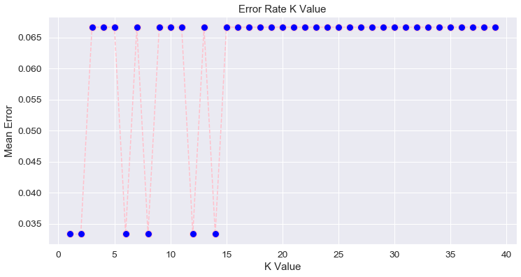

```python
plt.figure(figsize=(12, 6))
plt.plot(range(1, 40), error, color='pink', linestyle='dashed', marker='o',
         markerfacecolor='blue', markersize=10)
plt.title('Error Rate K Value')
plt.xlabel('K Value')
plt.ylabel('Mean Error')
```

Parameter Tuning with Cross Validation

```python
# creating odd list of K for KNN
from sklearn.model_selection import cross_val_score, KFold
neighbors = list(range(1, 50, 2))

# empty list that will hold cv scores
cvscores = []

# perform 10-fold cross validation
for k in neighbors:
    kn = KNeighborsClassifier(n_neighbors=k)
    scoresn = cross_val_score(kn, Xtrain, ytrain, cv=10, scoring='accuracy')
    cvscores.append(scoresn.mean())
```

```python
# creating odd list of K for KNN
from sklearn.model_selection import cross_val_score, KFold
neighbors = list(range(1, 50, 2))

# empty list that will hold cv scores
cv_scores = []

# perform 10-fold cross validation
for k in neighbors:
    knn = KNeighborsClassifier(n_neighbors=k)
    scores = cross_val_score(knn, Xtrain, ytrain, cv=10, scoring='accuracy')
    cv_scores.append(scores.mean())
```

```
The optimal number of neighbors is 1
```

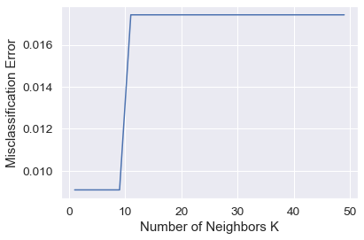

```python
# changing to misclassification error
mse = [1 - x for x in cv_scores]

# determining best k
optimal_k = neighbors[mse.index(min(mse))]
print("The optimal number of neighbors is {}".format(optimal_k))

# plot misclassification error vs k
plt.plot(neighbors, mse)
plt.xlabel("Number of Neighbors K")
plt.ylabel("Misclassification Error")
plt.show()
```

# Logistic Regression

It is a statistical method used for predicting the binary classes. Its target variale is dichotomous. Dichotomous means there are only two possible classes. a dichotomy is simply a split of a set into two mutually exclusive subsets whose union is the original set. Logistic regression is the special case of linear regression where the target variable is categorical in nature. It uses a log of odds as the dependent variable. It predicts the probability of occurrence of binary event utilizing a logit function.

Linear Regression Equation is as follows:-

```
y = β0 + β1X1 + β2X2 + ...... + βnXn
```

In the equation above, x1, x2 ... and Xn are explanatory variables and y is dependent variable

Sigmoid Function is represented as follows:

$ p = 1/1 + e^{-y} $

We can pply Sigmoid function on linear regression as follows:

$ p = 1/1 + e^{-(β0 + β1X1 + β2X2 + ...... + βnXn)} $

Logistic regression properties :-

- In logistic regression, the dependent variable follows Bernouilli Distribution.
- In logistic regression, estimation is done through maximum likelihood.

Logistic regression provides a constant output. Some of the examples of the discrete output is that predicting whether a person has a cancer or not, whether or not the transaction is fraud. logistic regression is estimated using Maximum Likelihood Estimation approach.

Model Development and Prediction :-

First we need to import the Logistic Regression module and create a Logistic Regression classifier object using LogisticRegression() function. Then we need to fit the model on the train set using fit() and perform prediction on the test set using predict().

```python
# import the class
from sklearn.linear_model import LogisticRegression

# instantiate the model (using the default parameters)
logreg = LogisticRegression()

# fit the model with data
logreg.fit(Xtrain,ytrain)

#
y_pred=logreg.predict(Xtest)
```

Model Evaluation using Confusion Matrix

To evaluate the performance of a classification model, we can use a confusion matrix table. In confusion matrix, the number of correct and incorrect predictions are summed up class-wise. By confusion matrix, we can also visualize the performance of an algorithm.

```python
# import the metrics class
from sklearn import metrics
cnf_matrix = metrics.confusion_matrix(ytest, y_pred)
cnf_matrix
```

```
array([[14,  0,  0],
       [ 0,  9,  1],
       [ 0,  0,  6]], dtype=int64)
```

Visualizing Confusion Matrix using Heatmap :-

We can visualize the results of the model in the form of a confusion matrix using matplotlib and seaborn.

Visualization of confusion matrix using Heatmap is as follows:-

```python
# import required modules
import numpy as np
import matplotlib.pyplot as plt
import seaborn as sns
%matplotlib inline
```

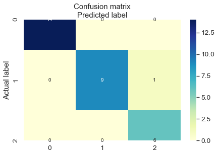

```python
class_names=[0,1] # name  of classes
fig, ax = plt.subplots()
tick_marks = np.arange(len(class_names))
plt.xticks(tick_marks, class_names)
plt.yticks(tick_marks, class_names)
# create heatmap
sns.heatmap(pd.DataFrame(cnf_matrix), annot=True, cmap="YlGnBu" ,fmt='g')
ax.xaxis.set_label_position("top")
plt.tight_layout()
plt.title('Confusion matrix', y=1.1)
plt.ylabel('Actual label')
plt.xlabel('Predicted label')
```

ROC Curve :- Receiver Operating Characteristic(ROC) curve is a plot of the true positive rate against the false positive rate. It shows the tradeoff between sensitivity and specificity.

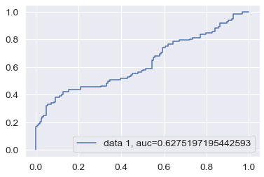

```python
y_pred_proba = logreg.predict_proba(X_test)[::,1]
fpr, tpr, _ = metrics.roc_curve(y_test,  y_pred_proba)
auc = metrics.roc_auc_score(y_test, y_pred_proba)
plt.plot(fpr,tpr,label="data 1, auc="+str(auc))
plt.legend(loc=4)
plt.show()
```

# Support Vector machine

A support vector machine (SVM) is a type of supervised machine learning classification algorithm.

Implementation of support vector machine is as follows:

```python
from sklearn.svm import SVC
svclassifier = SVC(kernel='linear')
svclassifier.fit(Xtrain, ytrain)
```

```
SVC(C=1.0, cache_size=200, class_weight=None, coef0=0.0,
    decision_function_shape='ovr', degree=3, gamma='auto_deprecated',
    kernel='linear', max_iter=-1, probability=False, random_state=None,
    shrinking=True, tol=0.001, verbose=False)
```

```python
ypredi = svclassifier.predict(Xtest)
```

```python
from sklearn.metrics import classification_report, confusion_matrix
print(confusion_matrix(ytest,ypredi))
print(classification_report(ytest,ypredi))
```

```
[[14  0  0]
 [ 0  9  1]
 [ 0  0  6]]
              precision    recall  f1-score   support

           0       1.00      1.00      1.00        14
           1       1.00      0.90      0.95        10
           2       0.86      1.00      0.92         6

    accuracy                           0.97        30
   macro avg       0.95      0.97      0.96        30
weighted avg       0.97      0.97      0.97        30
```

Kernel SVM1. Polynomial Kernel

In the case of polynomial kernel, you also have to pass a value for the degree parameter of the SVC class. This basically is the degree of the polynomial. Take a look at how we can use a polynomial kernel to implement kernel SVM:

```python
from sklearn.svm import SVC
svclassifier = SVC(kernel='poly', degree=8)
svclassifier.fit(Xtrain, ytrain)
```

```
SVC(C=1.0, cache_size=200, class_weight=None, coef0=0.0,
    decision_function_shape='ovr', degree=8, gamma='auto_deprecated',
    kernel='poly', max_iter=-1, probability=False, random_state=None,
    shrinking=True, tol=0.001, verbose=False)
```

Making Predictions

The predictions on test data is as follows:

```python
yprediction = svclassifier.predict(Xtest)
```

Evaluating the Algorithm

The final step of any machine learning algorithm is to make evaluations. we can make the evaluation by executing the following script:

The output for the kernel SVM using polynomial kernel looks like this:

```python
from sklearn.metrics import classification_report, confusion_matrix
print(confusion_matrix(ytest, yprediction))
print(classification_report(ytest, yprediction))
```

```
[[7 0 7]
 [0 3 7]
 [0 0 6]]
              precision    recall  f1-score   support

           0       1.00      0.50      0.67        14
           1       1.00      0.30      0.46        10
           2       0.30      1.00      0.46         6

    accuracy                           0.53        30
   macro avg       0.77      0.60      0.53        30
weighted avg       0.86      0.53      0.56        30
```

2. Gaussian Kernel

Gaussian Kernel is evaluated as follows:

```python
from sklearn.svm import SVC
svclassifier = SVC(kernel='rbf')
svclassifier.fit(Xtrain, ytrain)
```

```
SVC(C=1.0, cache_size=200, class_weight=None, coef0=0.0,
    decision_function_shape='ovr', degree=3, gamma='auto_deprecated',
    kernel='rbf', max_iter=-1, probability=False, random_state=None,
    shrinking=True, tol=0.001, verbose=False)
```

Prediction and Evaluation

The prediction on the test data is as follows:-

```python
ypred = svclassifier.predict(Xtest)
```

```python
from sklearn.metrics import classification_report, confusion_matrix
print(confusion_matrix(ytest, ypred))
print(classification_report(ytest, ypred))
```

```
[[14  0  0]
 [ 0  8  2]
 [ 0  0  6]]
              precision    recall  f1-score   support

           0       1.00      1.00      1.00        14
           1       1.00      0.80      0.89        10
           2       0.75      1.00      0.86         6

    accuracy                           0.93        30
   macro avg       0.92      0.93      0.92        30
weighted avg       0.95      0.93      0.93        30
```

3. Sigmoid Kernel

Finally, let's use a sigmoid kernel for implementing Kernel SVM. Take a look at the following script:

```python
from sklearn.svm import SVC
svclassifier = SVC(kernel='sigmoid')
svclassifier.fit(Xtrain, ytrain)
```

```
SVC(C=1.0, cache_size=200, class_weight=None, coef0=0.0,
    decision_function_shape='ovr', degree=3, gamma='auto_deprecated',
    kernel='sigmoid', max_iter=-1, probability=False, random_state=None,
    shrinking=True, tol=0.001, verbose=False)
```

To use the sigmoid kernel, you have to specify 'sigmoid' as value for the kernel parameter of the SVC class.

Prediction and Evaluation

```python
y_pred = svclassifier.predict(Xtest)
```

```python
from sklearn.metrics import classification_report, confusion_matrix
print(confusion_matrix(ytest, y_pred))
print(classification_report(ytest, y_pred))
```

```
[[14  0  0]
 [ 0  9  1]
 [ 0  0  6]]
              precision    recall  f1-score   support

           0       1.00      1.00      1.00        14
           1       1.00      0.90      0.95        10
           2       0.86      1.00      0.92         6

    accuracy                           0.97        30
   macro avg       0.95      0.97      0.96        30
weighted avg       0.97      0.97      0.97        30
```

Comparison of Kernel Performance:-

Research Question :-

What is the effects of Outliers on Support Vector Machines?

For both real world and artificial world dataset, significant results are difficult to attain using outlier-mitigating efforts such as fuzzy-SVMs over the standard SVMs. One must have a high level of noise in training set before test accuracies are significantly affected. SVMs are robust in the presence of noise i.e. outliers caused by mislabeled data.

# The Perceptron Learning Algorithm

A perceptron Model is a means of Supervised learning for Linearly separable dataset. The Perceptron can function as a classifier for linearly separable data sets. We can use an artificial dataset to study the perceptron learning algorithm. With this we can explore the algorithm further with datasets of different sizes and dimensions. A perceptron model classifies a datapoint on basis of the below formula.

${\displaystyle h(x) = sign((\sum _{i=1}^{d}w_{i}x_{i}})+ b)$,

It chooses a hypothesis by summing the product of weight vectors to the input data vector and adding a bias to it. In the above equation the bias can be replaced by a value ${\displaystyle w{n} }$ and a constant input vector of 1 which functions as ${\displaystyle x{n} }$. It can then reduces the equation above to ${\displaystyle h(x) = sign((\sum _{i=o}^{d}w_{i}x_{i}}))$. The Perceptron learning algorithm determines the correct weight vector by choosing a misclassified point on comparison with the target hypothesis, After that it updates the weight by the product of the classification and the input vector.

${\displaystyle w(t+1)= w(t)+y(t)x(t)}$.

For each update, the PLA then checks for misclassified points and moves the classfying hyperplane closer to the target hypothesis. The Perceptron learning algorithm(PLA) gaurantees convergence as long as the data is linearly separable.

The implementation is as follows:

```python
def generate_dataset(NoOfIn, FeaPerIn ):
    dset = np.vstack([
    np.ones(NoOfIn),
    np.random.uniform(-1,1,(FeaPerIn,NoOfIn))
    ])
    return np.transpose(dset)
```

```python
def generate_WeightVector(dimensions):
    return np.random.uniform(-1,1,(dimensions))
```

```python
def evaluate_hypothesis(DataA,weightsA):

    DataA = np.transpose(DataA)
    assert weightsA.shape[0] == DataA.shape[0]
    return np.sign(weightsA @ DataA)
```

```python
def pla(DataA,TargetClassification,misptseletype):

        weightA = np.zeros(DataA.shape[1])
        AllC = False
        iter=0
        #Iterating until all points are correctly classified
        while ~AllC :
            y=evaluate_hypothesis(DataA,weightA)
            # Picking a misclassified point
            Allpoints=y==TargetClassification

            if np.all(Allpoints):

                return weightA,iter
            if iter<10000:

                if misptseletype!='random':

                    selectedpoint=np.argmax(~Allpoints)
                else:


                    selectedpoint=random.choice([count for count,x in enumerate(Allpoints) if x == False])

                weightA += (TargetClassification[selectedpoint] *DataA[selectedpoint, :])
            else:
                AllC=True
                break
            iter+=1
        finalweight=weightA
        return finalweight,iter
```

```python
def ErrorRate(NoOfSample,Dimensions,ChosenV, TargetV):
    dataT=generate_dataset(NoOfSample, Dimensions)
    gy=evaluate_hypothesis(Data=dataT,weightsA=ChosenV)
    fy=evaluate_hypothesis(Data=dataT,weightsA=TargetV)
    Comparison=gy==fy
    return (np.size(Comparison)-np.count_nonzero(Comparison))/np.size(Comparison)*100
```

```python
def RunExperiment(SData,RPLA=True,PointSelectionType='Deterministically'):
    dimensionspace=np.array([-1, 1])
    datapoints=SData
    NoOfDimesnions=(SData.shape[1])-1
    TargetFVector=np.array([10, 15, -50])
    itr=0
    RTime=0
    ErrorRate=0

    if NoOfDimesnions!=2 and RPLA== True:
        TargetFVector=generate_WeightVector(dimensions=NoOfDimesnions+1)
        TargetClassification=evaluate_hypothesis(datapoints,TargetFVector)
        start = timeit.default_timer()
        Chosen_Vector_g,itr=pla(DataA=datapoints,TargetClassification=TargetClassification,misptseletype=PointSelectionType)
        stop = timeit.default_timer()
        print("Number of updates taken before converging",itr)
        RTime=stop - start
        print ('PLA Algorithm run time: '+str("%.4f" %RTime)+'seconds.')
        ErrorRate=ErrorRate(NumberOfSample=1000,Dimensions=NoOfDimesnions,ChosenVector=Chosen_Vector_g, TargetVector=TargetFVector)
        print ('ErrorRate for Selected Hypothesis is ',ErrorRate)


    TargetClassification=evaluate_hypothesis(datapoints,TargetFVector)
    if NoOfDimesnions==2 and RPLA== False:
        draw_plot(datapoints,TargetClassification)
        plot_hypothesis(dimensionspace, TargetFVector, 'g', label='Target Classifier')

    elif NoOfDimesnions==2 and RPLA== True :
        draw_plot(datapoints,TargetClassification)
        plot_hypothesis(dimensionspace, TargetFVector, 'g', label='Target Classifier')
        start = timeit.default_timer()
        Chosen_Vector_g,itr=pla(DataA=datapoints,TargetClassification=TargetClassification,misptseletype=PointSelectionType)
        stop = timeit.default_timer()
        RTime=stop - start
        plot_hypothesis(dimensionspace, Chosen_Vector_g, 'k--', label='Selected Hypothesis g')
        print("Number of updates taken before converging",itr)
        print ('PLA Algorithm run time: '+str("%.4f" % RTime)+'seconds.')
        ErrorRate=ErrorRate(NoOfSample=1000,Dimensions=NoOfDimesnions,ChosenVector=Chosen_Vector_g, TargetVector=TargetFVector)
        print ('ErrorRate for Selected Hypothesis is ',ErrorRate)
    return    TargetClassification,itr,RTime,ErrorRate
```

```python
def draw_plot(Data, Data_Classification):

    fig = plt.figure(figsize=(12,8))
    ax1 = fig.add_subplot(111)
    c1_data=[[],[]]
    c0_data=[[],[]]
    for count,val in enumerate(Data_Classification):
        cur_i1 = Data[count][1]
        cur_i2 = Data[count][2]
        if val==1:
            c1_data[0].append(cur_i1)
            c1_data[1].append(cur_i2)
        else:
            c0_data[0].append(cur_i1)
            c0_data[1].append(cur_i2)

    plt.title('Perceptron with Number of Samples = %s' % (str(len(Data_Classification))))
    plt.scatter(c0_data[0],c0_data[1], c='r',label="Class -1")
    plt.scatter(c1_data[0],c1_data[1], c='b',label="Class 1")
    plt.xlabel("X Axis")
    plt.ylabel("Y AXIS")

    ax1.legend(loc='center left', bbox_to_anchor=(1, 0.5))
```

```python
def plot_hypothesis(x_coordinates, w,*plot_args, **plot_kwargs):

    m = -w[1]/w[2] if w[2] != 0 else 0
    b = -w[0]/w[2] if w[2] != 0 else 0
    y_coordinates = m*x_coordinates + b
    plt.plot(x_coordinates, y_coordinates,*plot_args, **plot_kwargs)
    plt.legend(loc='center left', bbox_to_anchor=(1, 0.5))
```

```python
def PlotParameters(ParameterList,LabelList,ylabel,title):
    N = len(ParameterList)
    ind = np.arange(N)  # the x locations for the groups
    width = 0.2       # the width of the bars
    fig, ax = plt.subplots()
    rects1 = ax.bar(ind, ParameterList, width, color='b')

    ax.set_ylabel(ylabel)
    ax.set_title(title)
    ax.set_xticks((ind) + (width/2) / 2)
    ax.set_xticklabels(LabelList)

    def autolabel(rects):
        """
        Attach a text label above each bar displaying its height
        """
        for rect in rects:
            height = rect.get_height()
            ax.text(rect.get_x() + rect.get_width()/2, height,
                    '%.4f' % height,
                    ha='center', va='bottom')
    autolabel(rects1)
    plt.show()
```

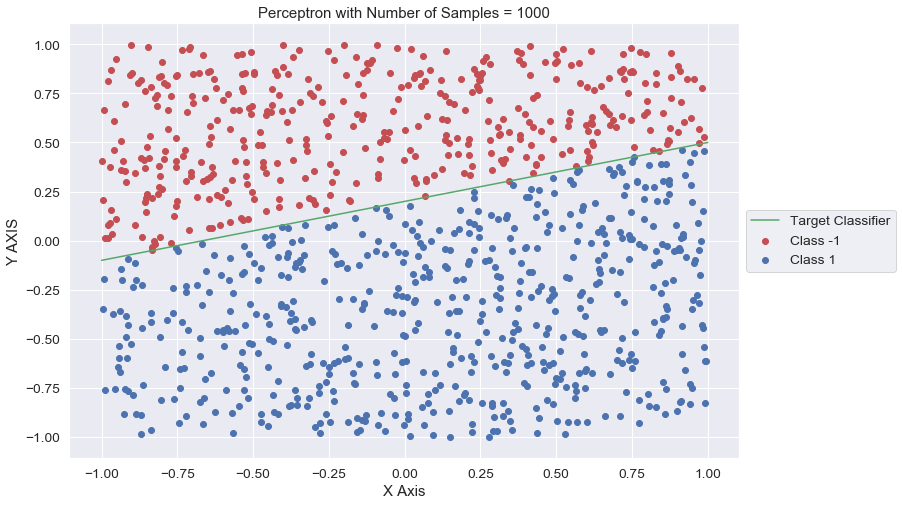

```python
X_N20_D2=generate_dataset(NoOfIn=1000,FeaPerIn=2)
Performance_Parameters_N20_D2=RunExperiment(SData=X_N20_D2,RPLA=False,PointSelectionType='Deterministically')
```

[output not shown]

[output not shown]

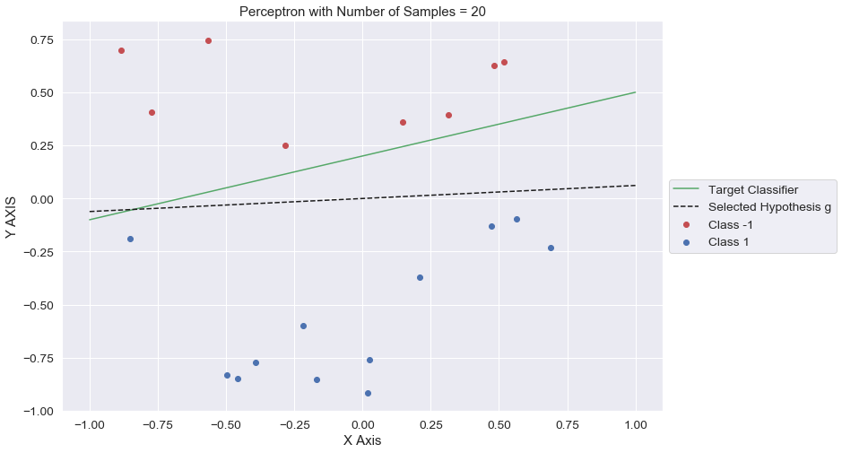

```python
X_New_N20_D2=generate_dataset(NoOfIn=20,FeaPerIn=2)
Performance_Parameters_New_N20_D2=RunExperiment(SData=X_New_N20_D2,RPLA=True,PointSelectionType='Deterministically')
```

Machine Learning Research Questions:-

$\bullet$ Which machine learning algorithm should be used when?  
The objective is to develop an theoretical understanding about when it is appropriate to use a perticular machine learning algorithm.

The answer to the question varies depending on many factors, which includes:

-The size, quality, and nature of data.  
-What you want to do with the data.  
-The available computational time.  
-The urgency of the task.

$\bullet$ What is the relationship between diiferent machine learning algorithms?  
The objective is to develop an theoretical understanding about what is the reationship between differnt machine learning algorithms.

$\bullet$ At what degree can we have both data privacy and the benefits of data mining?

Cryptographic approaches is used for data privacy and the benefits of data mining .

$\bullet$ Will computer perception merge with machine learning?  
e.g., incorporation of multiple sensory modalities such as vision, sound, touch to provide a setting in which self-supervised learning could be applied to predict one sensory experience from the others.

$\bullet$ How to develop learning algorithms that’re trained on one distribution and generalize well to another?  
It is an important research area or problem to develop learning algorithms that’re trained on one distribution and generalize well to another.

Conclusion :-

The problem of this project is a classification problem. In this project, the machine learning algorithms such as Logistic Regression, Support Vecor Machine, K nearest neighbors, and perceptron learning algorithm for classification problem is implemented. The problem is implemented on a real world dataset and synthetic dataset.